# Main Code

Binh Le, Elise Rodriguez, & Daphnie Tian

Fall 2023

## Data

### Importing Data

In this section, we have imported our datasets as `xts` objects in their respective chunks:

- `data_gni_pca` (Gini Index)
- `data_rad` (R&D Expenditure)
- `data_gdp` (GDP)
- `data_unp` (Unemployment, Total)
- `data_unp_edu` (Unemployment, Basic Education)
- `data_gni` (GNI)
- `data_gni_pca` (GNI per Capita)

### Creating Sub-Groups Based on GNI per Capita

In this section, we have split each country included in our data into the following categories (with their criteria):

| Category | Variable | Minimum | Maximum |
| --- | --- | --- | --- |
| low-income countries | lic | 0 | 1,025 |
| middle-income countries | mic | 1,025 | 12,475 |
| high-income countries | hic | 12,475 | NA |
| no observations | nob | NA | NA |

Each country’s GNI per capita (`gni_pca`) is based on its most recent observation. Each observation is measured in 2015 USD.

Based on our observations, we find the categories have the following totals:

| Category | Variable | Observations |
| --- | --- | --- |
| low-income countries | lic | 24 |
| middle-income countries | mic | 108 |
| high-income countries | hic | 68 |
| no observations | nob | 17 |

We included the average in this categorization process.

### Possibly Excluding Countries

In this section, we are considering exlcuding countries based on the two criteria below:

1. Fewer than 5 observations
2. No data in the past five years

### Subsetting by Number of Observations

In this section, have considered how many observations the countries in our datasets have. We have plotted below the different classes (listed below) for each dataset as noted in the figure titles.

### Creating Lags for R&D

```
##
## Call:
## lm(formula = gini ~ rad + lg1 + lg2 + lg3 + lg4 + lg5 + lg6 +
##     lg7 + lg8 + lg9 + lg10, data = data_reg_rad_gini)
##
## Coefficients:
## (Intercept)          rad          lg1          lg2          lg3          lg4
##     35.7427      -1.9503       1.6521      -1.2869       2.9384      -1.8695
##         lg5          lg6          lg7          lg8          lg9         lg10
##      0.2550      -0.1284      -0.2760      -0.2225       2.0052      -2.6804
```

```
##
## Call:
## lm(formula = unp ~ rad + lg1 + lg2 + lg3 + lg4 + lg5 + lg6 +
##     lg7 + lg8 + lg9 + lg10, data = data_reg_rad_unp)
##
## Coefficients:
## (Intercept)          rad          lg1          lg2          lg3          lg4
##      8.5697      -0.3433       1.4548       1.0184      -0.6900       0.2220
##         lg5          lg6          lg7          lg8          lg9         lg10
##      0.1257      -2.7676       0.3914      -1.2012       0.6479       0.3251
```

## Plotting our Data

In this section, we have generated various plots as shown below.

### Figure 1: R&D Expenditure against Gini Index

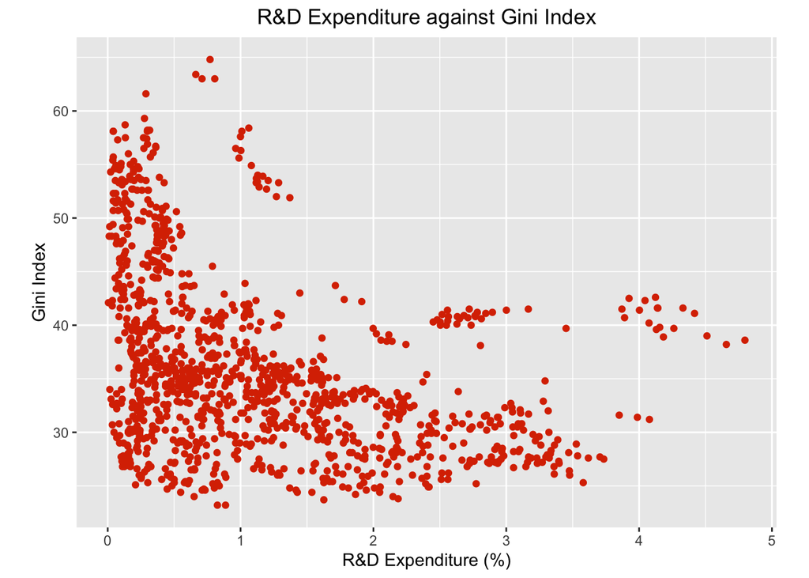

### Figure 2: R&D Expenditure against Gini Index (USA)

[figure not shown]

Figures 3 - 5 were removed because they included the World Average measure, which we deleted.

### Figure 6: R&D Expenditure against Gini Index & Unemployment (USA)

[figure not shown]

### Figure 8: Number of Observations for Gini Data

[figure not shown]

### Figure 9: Number of Observations for R&D Data

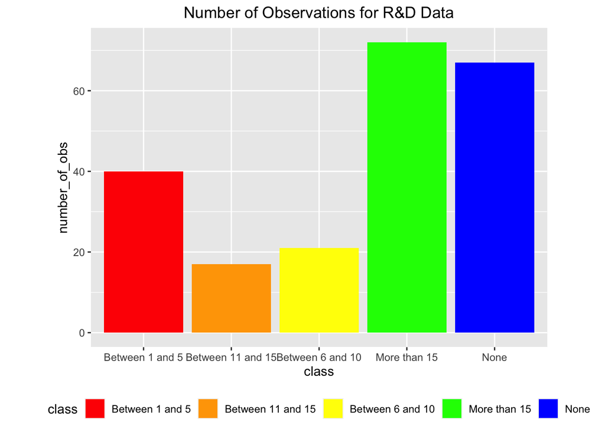

### Figure 10: Number of Observations for GDP Data

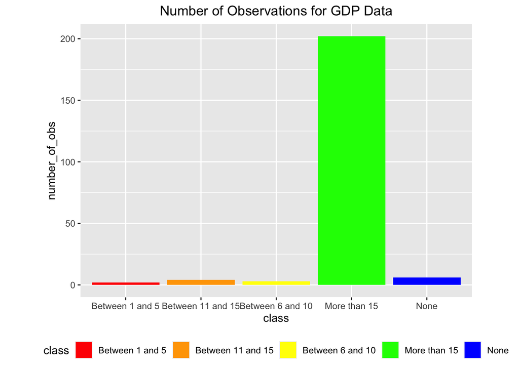

### Figure 11: Number of Observations for Unemployment Data

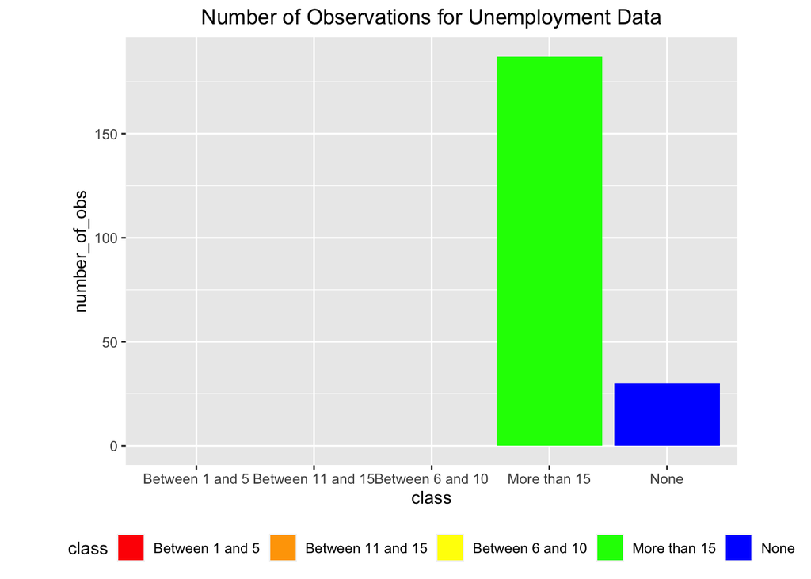

### Figure 12: Number of Observations for Unemployment (Basic) Data

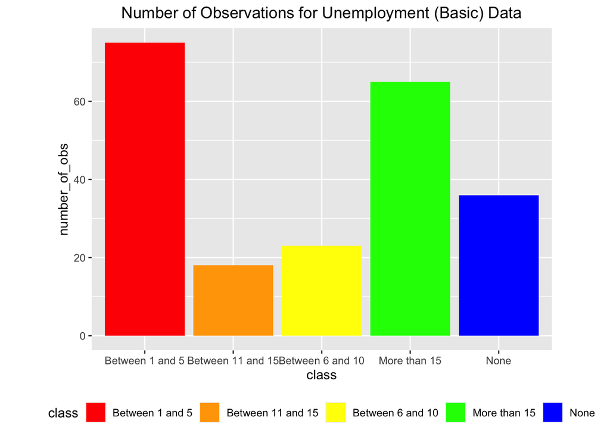

### Figure 13: Number of Observations for GNI Data

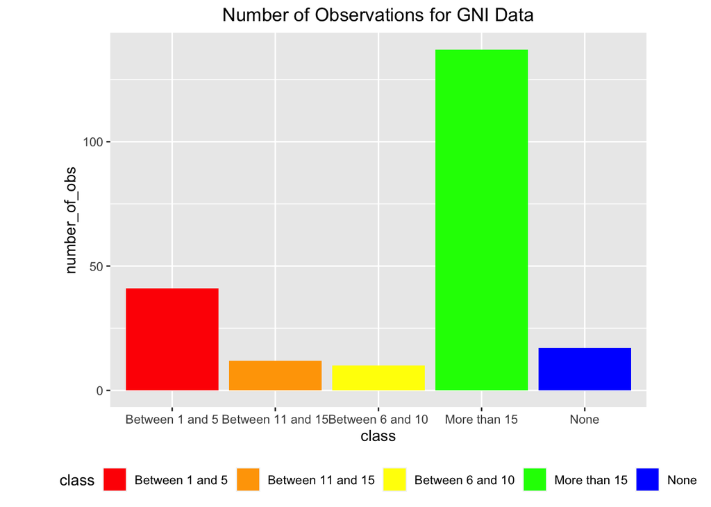

### Figure 14: Number of Observations for GNI per Capita Data

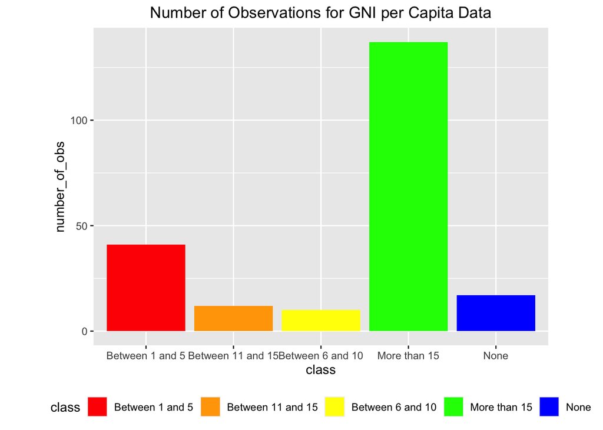